# FinalProject

Leonardo Placidi

SMDS 2 2019-2020, prof. Tardella

The Dataset I will use in this project is composed of data from the online videogame League of Legends(created in 2009). To obtain this data I personally interacted with the Riot(the company onwer of the game and data) API with a medium size python script (as the parsers are mostly in python). The script to download the data can be found on GitHub on this link https://github.com/Gruntrexpewrus/FinalProjectSMDS2/blob/master/LeagueOfLegendsDataCollection.ipynb.

League of Legends is famous for its ranked system and going from lowest to highest ranks the tiers are Iron, Bronze, Silver, Gold, Platinum, Diamond, Master, Grandmaster, Challenger. Every tier up until Diamond has 4 ranks called from the bottom IV, III, II, I, then the system changes with only a points distribution in the limited final posititons. The distribution of players is such that 88% are Gold or below and around 0.07% of all players are Master or Above.

The Data I am using are from the Ranked Solo/Duo games from the EUW server of the game, which has around 6 millions of players. Data are taken from every tier except Master/GM/Challenger, since they present different characteristics. I took the rank IV for every tier and as only 5.7% of players are in Iron, to get enough data I had to get Iron IV and Iron III data, since Iron IV is as difficult to be in as being in Challenger!

In the table that will be shown after this introduction we can see that for every index (X in the column), we have the player’s tier (in this case Gold since I started from this rank, the reason is that I wanted to first include my profile in the data!), then the summonerName, the in-game-name, the leaguePoints that are the points to reach the higher rank (e.g from Gold IV to Gold III, I will specify more later), the wins until now, the losees until now, and finally if the players is a veteran of the game or not (veteran means he played ranked games multiple years).  
To Specify better the leaguePoints, we shall say that they go from 0 to 100, at every win the player will get some points, to a loss will lose some, and arrivged at 100 there is a promotions system to win 2/3 games in order to reach the highest rank. When you fail a promotion series you are given a free win next time you go in promotion, while to change Tier (e.g from Gold to Platinum) you have to win 3/5 games in a promotion series and will get free wins up to 2 wins for failed promotions. When you lose many games at 0 LP you will eventually get demoted, being set at around 70 LP in the lower Rank (e.g. demoted from Gold 4 to Silver1), but demotions that are usually 3 games lost at 0 LP, can be up to 10 games from a tier to the other (To fall from Gold III to Gold 4 you can lose 3 games at 0 LP, while to go from Gold 4 to Silver 1 you should lose > 10 games at 0 LP, depending on a secret ‘elo’ system of the player called MMR that recognize the ‘current ability’ and then the rank of a player).

The aim of the project will be stated later, but I introduce saying that our variable of interest will be the wins and I will try to predict them given the other features(In particular the rank) for every player.

Now let’s do some exploratory data analysis, to know better our dataset and the features we will be working with.

```r
set.seed(123)
require(tidyverse)
```

```r
require(ggplot2)
require(VGAM)
require(R2jags)
require(mcmcse)
require(bayesplot)
require(TeachingDemos)
require(nimble)
require(sadists)
require(EnvStats)
require(sadists)
require(stats)
require(rmutil)
```

# 1) Illustration of the dataset

In the following I will show many different perspectives from which we can watch our dataset, taking advantage of our conclusions to discard some features and understand the trend, importance and correltions of the others!

We highlight that the main aim of the project is to create a model to predict wins, so this will be our main variable of interest.

```r
set.seed(123)
LeagueData <- read.csv("ProjectFinaldataLeagueofLegends.csv")
#Let's first drop the column X since we already have automatic indexes
LeagueData = subset(LeagueData, select = -c(X) )
head(LeagueData)
```

```
##   tier     summonerName leaguePoints wins losses veteran
## 1 GOLD           T0kki3           52  183    169    True
## 2 GOLD    CrimsÃ\230nBlade            0   52     49   False
## 3 GOLD     I LIKE FLIES          100   56     56   False
## 4 GOLD     DaKin Kowine            2  197    191   False
## 5 GOLD AnatolÃ®an eagle            0    2     10   False
## 6 GOLD     TOXIC I Himi           18  174    197   False
```

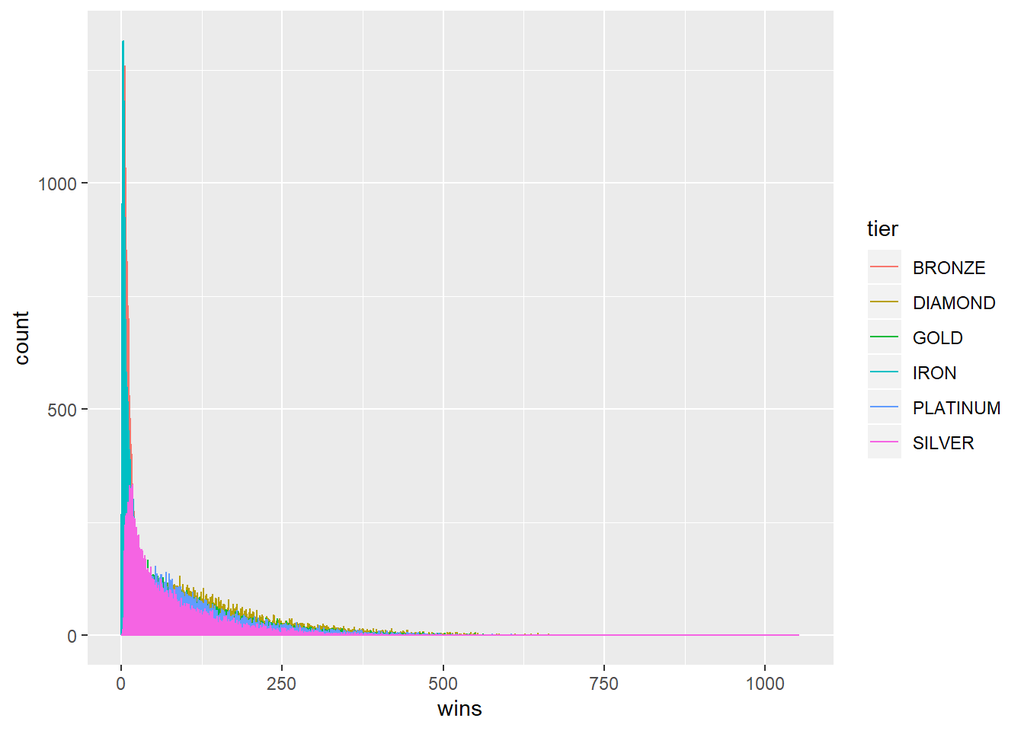

```r
#Now let's explore the distribution of the wins
ggplot(data = LeagueData, mapping = aes(x = wins, colour = tier)) +

  geom_freqpoly(binwidth = 0.1)
```

```
## [1] "GOLD"
```

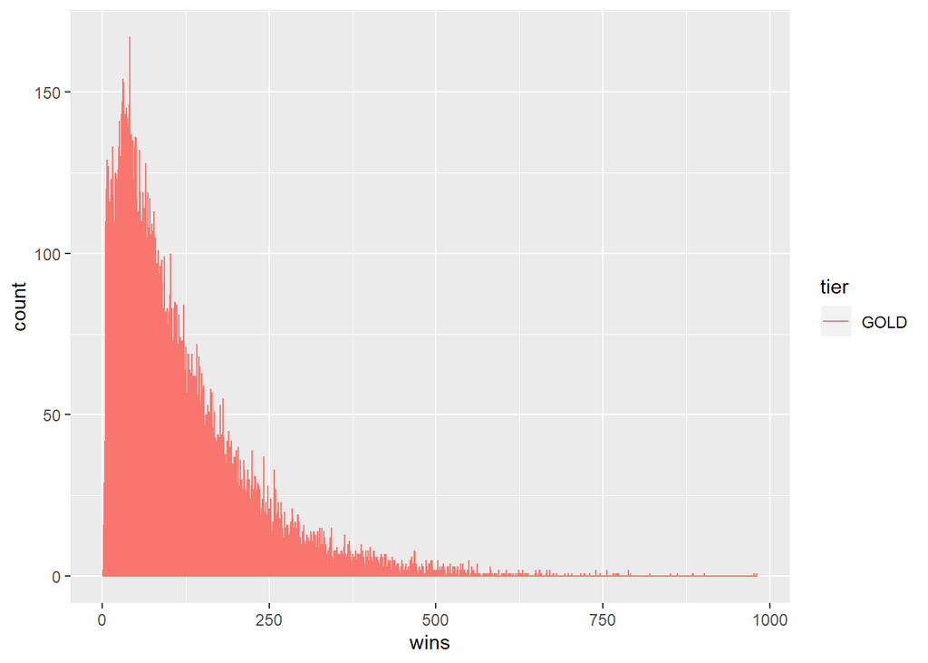

```
## [1] "IRON"
```

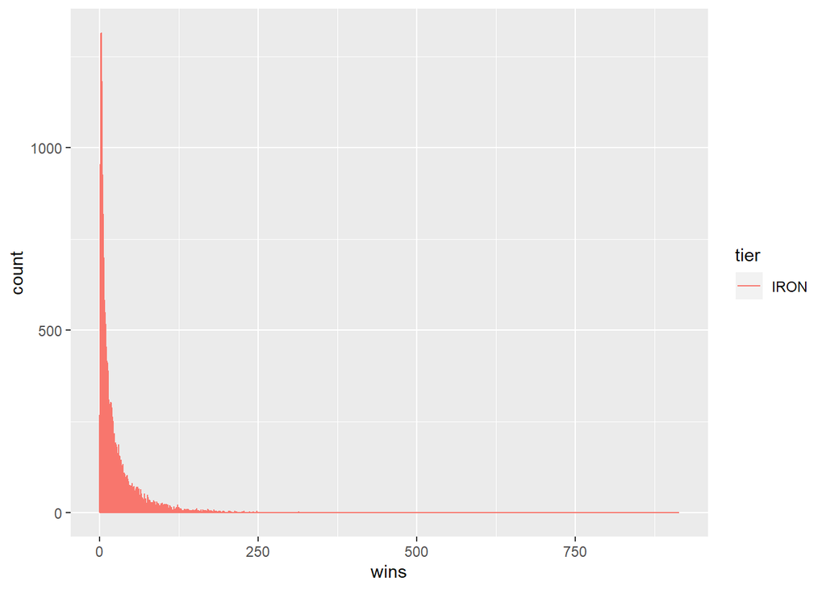

```
## [1] "BRONZE"
```

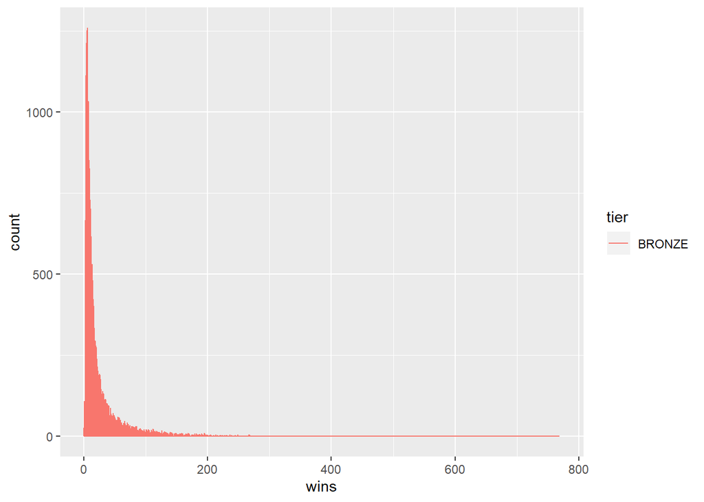

```
## [1] "SILVER"
```

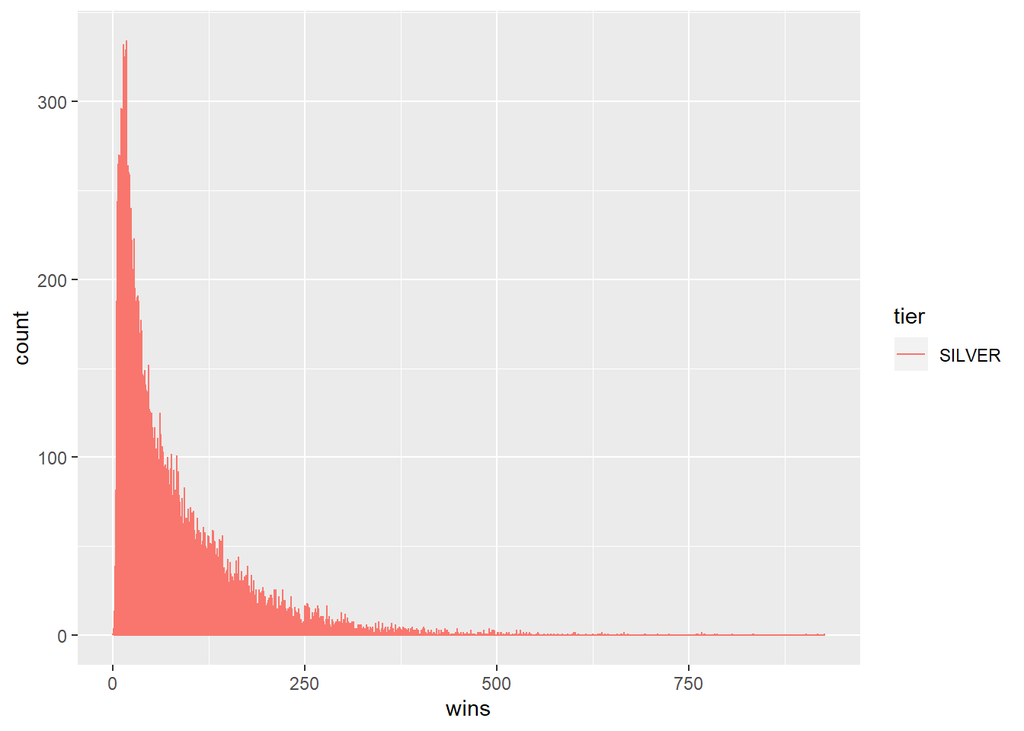

```
## [1] "PLATINUM"
```

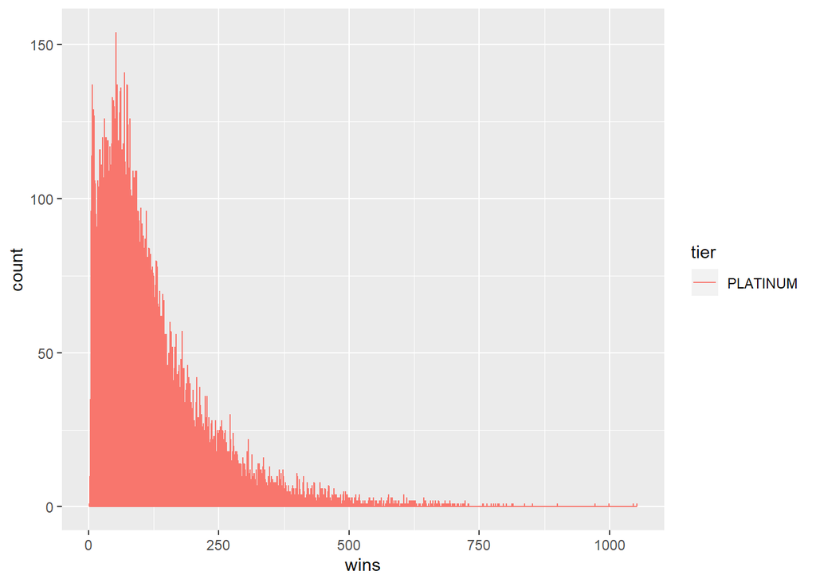

```
## [1] "DIAMOND"
```

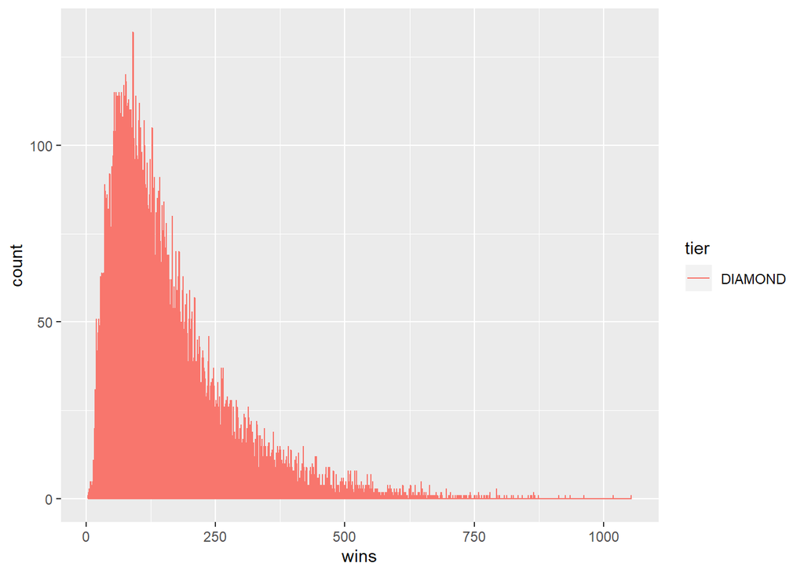

```r
#Actually is a little confused so let's try to see only for gold
#subset(LeagueData, tier == 'GOLD')
for( i in unique(LeagueData$tier)){
  print(i)
  plot2 <-  ggplot(data = subset(LeagueData, tier == i), mapping = aes(x = wins, colour = tier)) +
     geom_freqpoly(binwidth = 0.1)
  print(plot2)
  }
```

```
## [1] "GOLD"
```

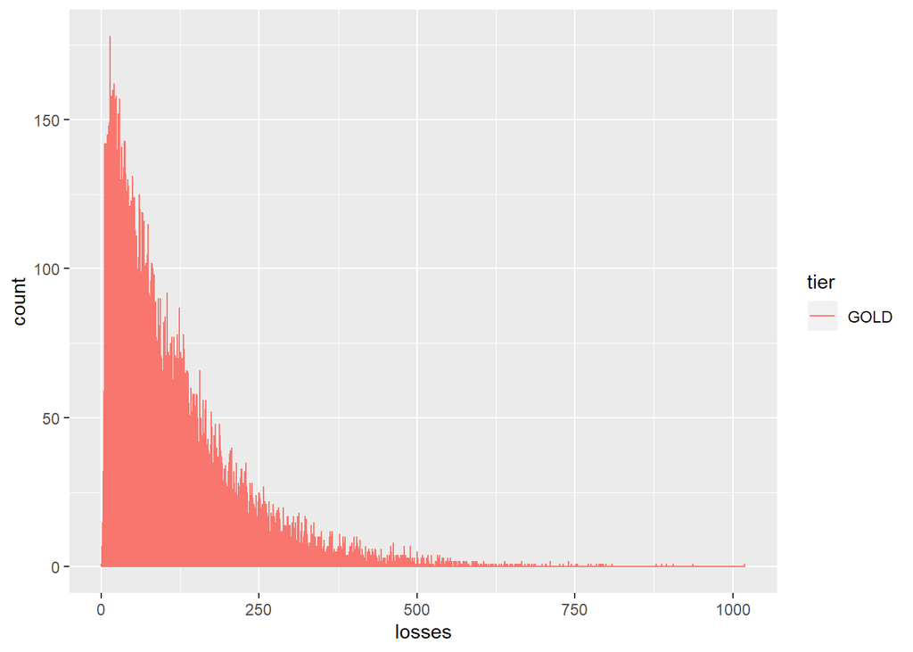

```
## [1] "IRON"
```

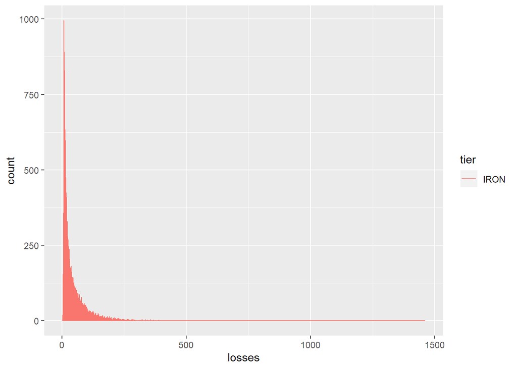

```
## [1] "BRONZE"
```

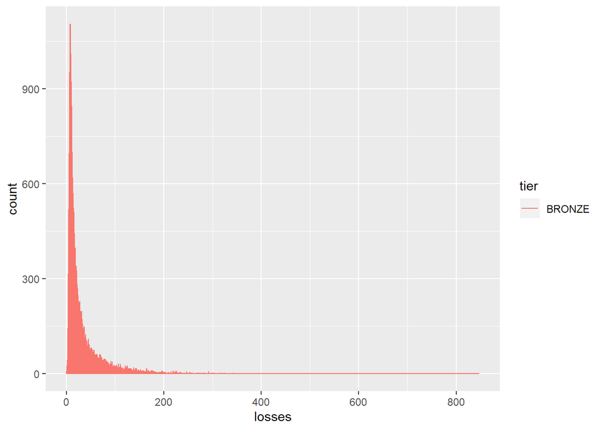

```
## [1] "SILVER"
```

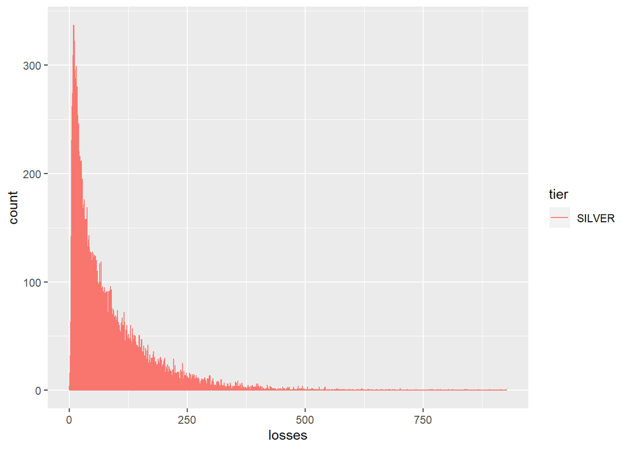

```
## [1] "PLATINUM"
```

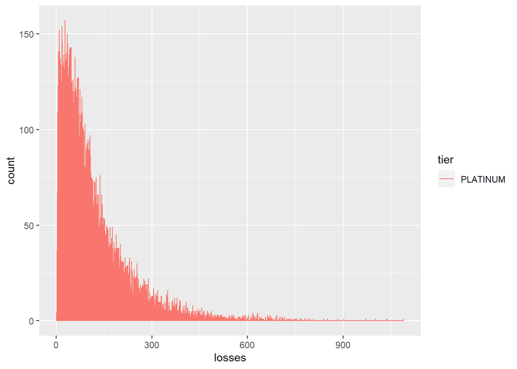

```
## [1] "DIAMOND"
```

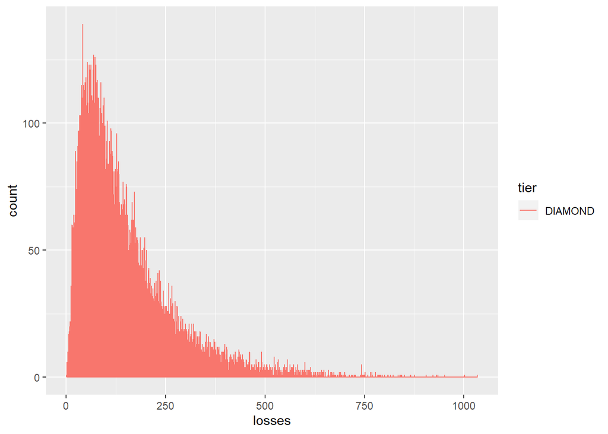

```r
for( i in unique(LeagueData$tier)){
  print(i)
  plot2 <-  ggplot(data = subset(LeagueData, tier == i), mapping = aes(x = losses, colour = tier)) +
     geom_freqpoly(binwidth = 0.1)
  print(plot2)
  }
```

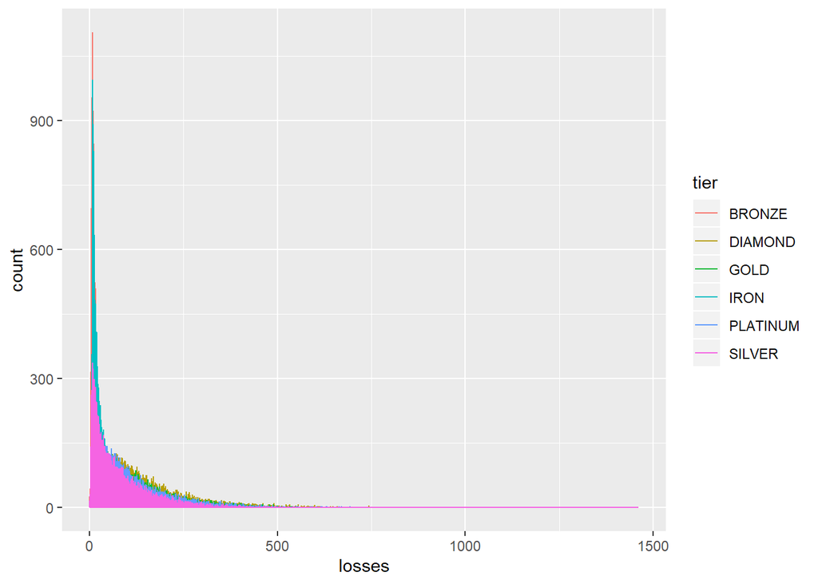

```r
#Now let's explore the distribution of the losses
ggplot(data = LeagueData, mapping = aes(x = losses, colour = tier)) +

  geom_freqpoly(binwidth = 0.1)
```

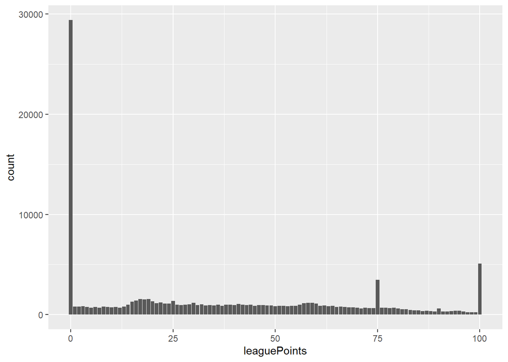

```r
#as we suspected they shuld be correlated! and they will sure be similar distirbutions!


#Now let's explore the distribution of the leaguePoints
ggplot(data = LeagueData) +
  geom_bar(mapping = aes(x = leaguePoints)) #pretty uniform! even if in 0 there is a great concentration of values
```

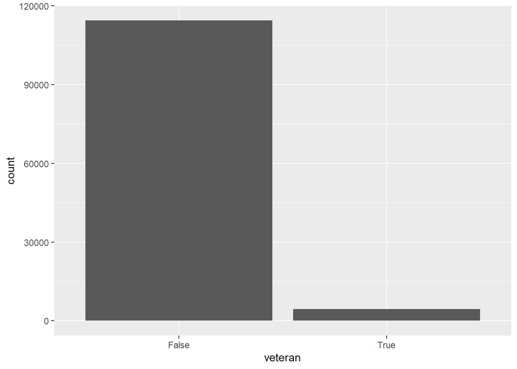

```r
#Now let's explore the distribution of the veterans
ggplot(data = LeagueData) +
  geom_bar(mapping = aes(x = veteran))
```

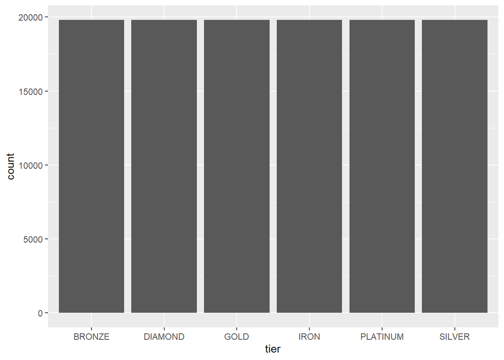

```r
#since veterans are very few we could discard this variable and we will not use it for our analysis



#Now let's explore the distribution of the Tier
ggplot(data = LeagueData) +
  geom_bar(mapping = aes(x = tier))
```

```r
#a little trick, i creted the dataset such that every tier will have the same number of elements!!!!
```

From here we immediately undeerstand that the game is balanced and the we will expect that win and losses will have the same distribution, making impossible to assume on one and predict the others, they will be alwasy taken singularly or we could consider the winrate, but let’s stick with the wins!

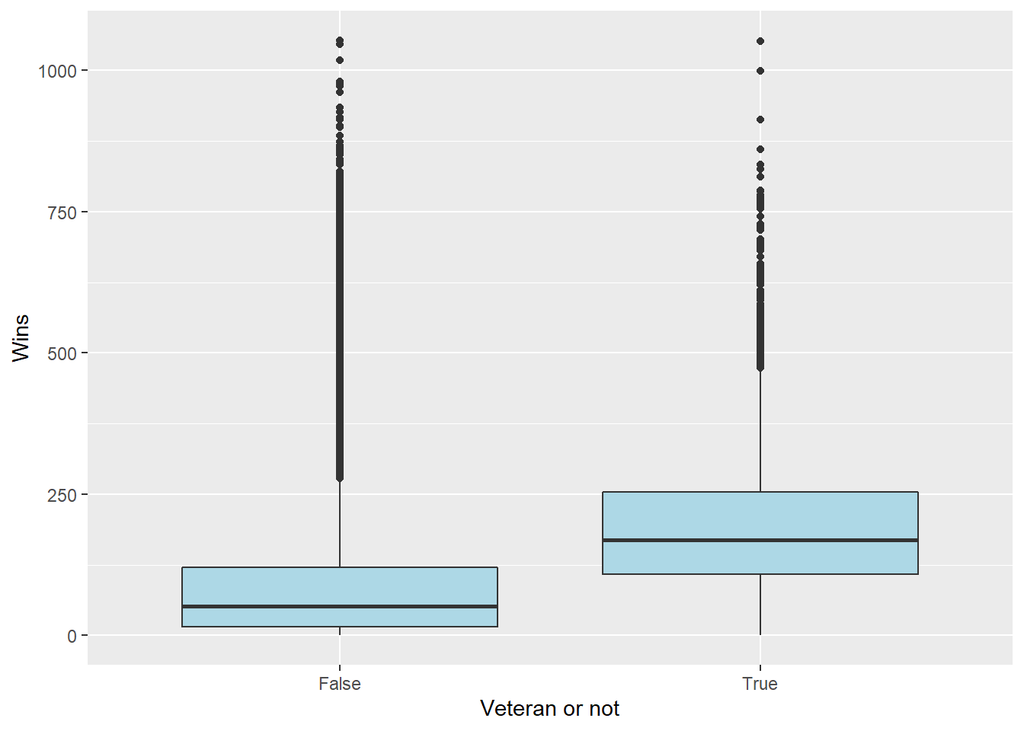

```r
require(tidyverse)
qplot(x = LeagueData$veteran, y = LeagueData$wins,
      geom = "boxplot", data = LeagueData,
      xlab = "Veteran or not",
      ylab = "Wins",
      fill = I("lightblue"))
```

```r
#we see from here that the few veterans (that we will not consider as a feature sigh) win more games!!!
```

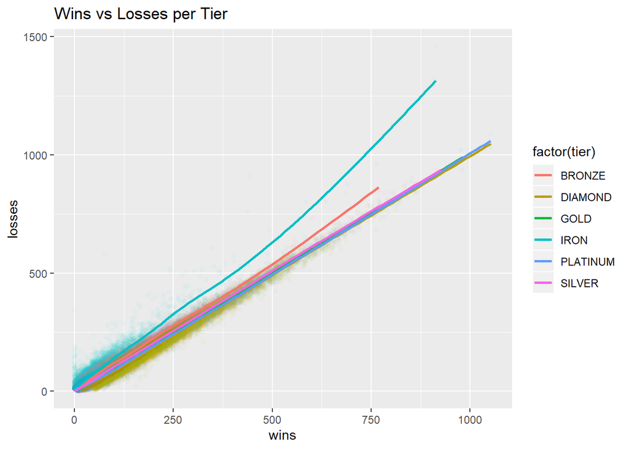

```r
#Now we can ask ourselves if in every tier the losses and wins are actually correlated, let's see!

ggplot(LeagueData, aes(x=wins, y=losses, colour=factor(tier))) +
    geom_point(alpha=.03) +
    geom_smooth(method = "gam", formula = y ~ s(x, bs = "cs"),alpha=.02, size=1) +
    ggtitle("Wins vs Losses per Tier")
```

```r
#So here is clear we have a linear relation between wins and losses (in every tier!)!
```

Another time is clear that losses and wins are very related and so will be necessary to just choose one of them for our model.

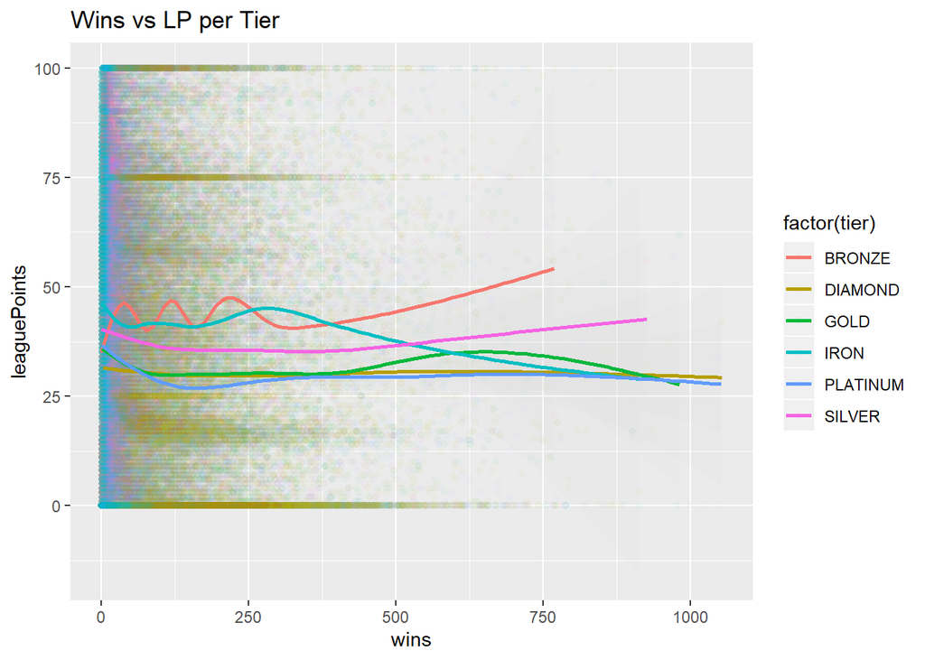

```r
# Now let's see the same plot as before but instead of the losses we will consider the LP
ggplot(LeagueData, aes(x=wins, y=leaguePoints, colour=factor(tier))) +
    geom_point(alpha=.03) +
    geom_smooth(method = "gam", formula = y ~ s(x, bs = "cs"),alpha=.02, size=1) +
    ggtitle("Wins vs LP per Tier")
```